# (Ford GoBike System Data)

## Preliminary Wrangling

> This dataset includes information about individual rides made in a bike-sharing system covering the greater San Francisco Bay area.

```python
# import all packages and set plots to be embedded inline
import numpy as np
import pandas as pd
import matplotlib.pyplot as plt
import seaborn as sb

%matplotlib inline
```

### 1. Gathering

Gathering the Ford GoBike System Dataset as a file on hand source.

```python
# reading the dataset as df
df = pd.read_csv('201902-fordgobike-tripdata.csv')
df
```

|  | duration_sec | start_time | end_time | start_station_id | start_station_name | start_station_latitude | start_station_longitude | end_station_id | end_station_name | end_station_latitude | end_station_longitude | bike_id | user_type | member_birth_year | member_gender | bike_share_for_all_trip |
| --- | --- | --- | --- | --- | --- | --- | --- | --- | --- | --- | --- | --- | --- | --- | --- | --- |
| 0 | 52185 | 2019-02-28 17:32:10.1450 | 2019-03-01 08:01:55.9750 | 21.0 | Montgomery St BART Station (Market St at 2nd St) | 37.789625 | -122.400811 | 13.0 | Commercial St at Montgomery St | 37.794231 | -122.402923 | 4902 | Customer | 1984.0 | Male | No |
| 1 | 42521 | 2019-02-28 18:53:21.7890 | 2019-03-01 06:42:03.0560 | 23.0 | The Embarcadero at Steuart St | 37.791464 | -122.391034 | 81.0 | Berry St at 4th St | 37.775880 | -122.393170 | 2535 | Customer | NaN | NaN | No |
| 2 | 61854 | 2019-02-28 12:13:13.2180 | 2019-03-01 05:24:08.1460 | 86.0 | Market St at Dolores St | 37.769305 | -122.426826 | 3.0 | Powell St BART Station (Market St at 4th St) | 37.786375 | -122.404904 | 5905 | Customer | 1972.0 | Male | No |
| 3 | 36490 | 2019-02-28 17:54:26.0100 | 2019-03-01 04:02:36.8420 | 375.0 | Grove St at Masonic Ave | 37.774836 | -122.446546 | 70.0 | Central Ave at Fell St | 37.773311 | -122.444293 | 6638 | Subscriber | 1989.0 | Other | No |
| 4 | 1585 | 2019-02-28 23:54:18.5490 | 2019-03-01 00:20:44.0740 | 7.0 | Frank H Ogawa Plaza | 37.804562 | -122.271738 | 222.0 | 10th Ave at E 15th St | 37.792714 | -122.248780 | 4898 | Subscriber | 1974.0 | Male | Yes |
| ... | ... | ... | ... | ... | ... | ... | ... | ... | ... | ... | ... | ... | ... | ... | ... | ... |
| 183407 | 480 | 2019-02-01 00:04:49.7240 | 2019-02-01 00:12:50.0340 | 27.0 | Beale St at Harrison St | 37.788059 | -122.391865 | 324.0 | Union Square (Powell St at Post St) | 37.788300 | -122.408531 | 4832 | Subscriber | 1996.0 | Male | No |
| 183408 | 313 | 2019-02-01 00:05:34.7440 | 2019-02-01 00:10:48.5020 | 21.0 | Montgomery St BART Station (Market St at 2nd St) | 37.789625 | -122.400811 | 66.0 | 3rd St at Townsend St | 37.778742 | -122.392741 | 4960 | Subscriber | 1984.0 | Male | No |
| 183409 | 141 | 2019-02-01 00:06:05.5490 | 2019-02-01 00:08:27.2200 | 278.0 | The Alameda at Bush St | 37.331932 | -121.904888 | 277.0 | Morrison Ave at Julian St | 37.333658 | -121.908586 | 3824 | Subscriber | 1990.0 | Male | Yes |
| 183410 | 139 | 2019-02-01 00:05:34.3600 | 2019-02-01 00:07:54.2870 | 220.0 | San Pablo Ave at MLK Jr Way | 37.811351 | -122.273422 | 216.0 | San Pablo Ave at 27th St | 37.817827 | -122.275698 | 5095 | Subscriber | 1988.0 | Male | No |
| 183411 | 271 | 2019-02-01 00:00:20.6360 | 2019-02-01 00:04:52.0580 | 24.0 | Spear St at Folsom St | 37.789677 | -122.390428 | 37.0 | 2nd St at Folsom St | 37.785000 | -122.395936 | 1057 | Subscriber | 1989.0 | Male | No |

183412 rows × 16 columns

### 2. Assessing

```python
# show breif information about the dataset
df.info()
```

```
<class 'pandas.core.frame.DataFrame'>
RangeIndex: 183412 entries, 0 to 183411
Data columns (total 16 columns):
 #   Column                   Non-Null Count   Dtype
---  ------                   --------------   -----
 0   duration_sec             183412 non-null  int64
 1   start_time               183412 non-null  object
 2   end_time                 183412 non-null  object
 3   start_station_id         183215 non-null  float64
 4   start_station_name       183215 non-null  object
 5   start_station_latitude   183412 non-null  float64
 6   start_station_longitude  183412 non-null  float64
 7   end_station_id           183215 non-null  float64
 8   end_station_name         183215 non-null  object
 9   end_station_latitude     183412 non-null  float64
 10  end_station_longitude    183412 non-null  float64
 11  bike_id                  183412 non-null  int64
 12  user_type                183412 non-null  object
 13  member_birth_year        175147 non-null  float64
 14  member_gender            175147 non-null  object
 15  bike_share_for_all_trip  183412 non-null  object
dtypes: float64(7), int64(2), object(7)
memory usage: 22.4+ MB
```

```python
# check the missing values
df.isna().sum()
```

```
duration_sec                  0
start_time                    0
end_time                      0
start_station_id            197
start_station_name          197
start_station_latitude        0
start_station_longitude       0
end_station_id              197
end_station_name            197
end_station_latitude          0
end_station_longitude         0
bike_id                       0
user_type                     0
member_birth_year          8265
member_gender              8265
bike_share_for_all_trip       0
dtype: int64
```

```python
# check the unique values of user_type column
df['user_type'].unique()
```

```
array(['Customer', 'Subscriber'], dtype=object)
```

```python
# check the unique values of member_gender column
df['member_gender'].unique()
```

```
array(['Male', nan, 'Other', 'Female'], dtype=object)
```

```python
# check the unique values of bike_share_for_all_trip column
df['bike_share_for_all_trip'].unique()
```

```
array(['No', 'Yes'], dtype=object)
```

```python
# display descriptive statistics
df.describe()
```

|  | duration_sec | start_station_id | start_station_latitude | start_station_longitude | end_station_id | end_station_latitude | end_station_longitude | bike_id | member_birth_year |
| --- | --- | --- | --- | --- | --- | --- | --- | --- | --- |
| count | 183412.000000 | 183215.000000 | 183412.000000 | 183412.000000 | 183215.000000 | 183412.000000 | 183412.000000 | 183412.000000 | 175147.000000 |
| mean | 726.078435 | 138.590427 | 37.771223 | -122.352664 | 136.249123 | 37.771427 | -122.352250 | 4472.906375 | 1984.806437 |
| std | 1794.389780 | 111.778864 | 0.099581 | 0.117097 | 111.515131 | 0.099490 | 0.116673 | 1664.383394 | 10.116689 |
| min | 61.000000 | 3.000000 | 37.317298 | -122.453704 | 3.000000 | 37.317298 | -122.453704 | 11.000000 | 1878.000000 |
| 25% | 325.000000 | 47.000000 | 37.770083 | -122.412408 | 44.000000 | 37.770407 | -122.411726 | 3777.000000 | 1980.000000 |
| 50% | 514.000000 | 104.000000 | 37.780760 | -122.398285 | 100.000000 | 37.781010 | -122.398279 | 4958.000000 | 1987.000000 |
| 75% | 796.000000 | 239.000000 | 37.797280 | -122.286533 | 235.000000 | 37.797320 | -122.288045 | 5502.000000 | 1992.000000 |
| max | 85444.000000 | 398.000000 | 37.880222 | -121.874119 | 398.000000 | 37.880222 | -121.874119 | 6645.000000 | 2001.000000 |

```python
# check for duplicated records
df.duplicated().sum()
```

```
0
```

### Issues

**Quality**

- There are some missing value.
- Unneeded columns (start_station_id, start_station_latitude, start_station_longitude, end_station_id, end_station_latitude & end_station_longitude).
- Datatype to be changed:
  - start_time & end_time best to be datetime instead of object.
  - bike_id best to be object.
  - member_birth_year best to be intger instead of float.
- duration_sec values best to be in minutes instead of seconds.

**Tidiness**

- Generate new column for a new variable (member_age) from the member_birth_year.
- Both start_time & end_time columns contain Multi variables.

### 3. Cleaning

```python
# first step is making a copy of the dataframe
df_clean = df.copy()
```

### Issue 1:

There are some missing value.

**Define**

- Drop the records with null values in these columns (start_station_id, start_station_name, end_station_id, end_station_name, member_birth_year & member_gender).

**Code**

```python
# drop the records with null values
df_clean.dropna(inplace = True)
```

**Test**

```python
# check the missing values is gone
df_clean.isna().sum()
```

```
duration_sec               0
start_time                 0
end_time                   0
start_station_id           0
start_station_name         0
start_station_latitude     0
start_station_longitude    0
end_station_id             0
end_station_name           0
end_station_latitude       0
end_station_longitude      0
bike_id                    0
user_type                  0
member_birth_year          0
member_gender              0
bike_share_for_all_trip    0
dtype: int64
```

### Issue 2:

Unneeded columns (start_station_id, start_station_latitude, start_station_longitude, end_station_id, end_station_latitude & end_station_longitude).

**Define**

- Drop these columns (start_station_id, start_station_latitude, start_station_longitude, end_station_id, end_station_latitude & end_station_longitude).

**Code**

```python
# Drop start_station_latitude, start_station_longitude, end_station_latitude & end_station_longitude columns.
df_clean.drop(['start_station_id','start_station_latitude', 'start_station_longitude','end_station_id','end_station_latitude','end_station_longitude'], axis = 1, inplace = True)
```

**Test**

```python
# check the unneeded columns are gone
df_clean.info()
```

```
<class 'pandas.core.frame.DataFrame'>
Int64Index: 174952 entries, 0 to 183411
Data columns (total 10 columns):
 #   Column                   Non-Null Count   Dtype
---  ------                   --------------   -----
 0   duration_sec             174952 non-null  int64
 1   start_time               174952 non-null  object
 2   end_time                 174952 non-null  object
 3   start_station_name       174952 non-null  object
 4   end_station_name         174952 non-null  object
 5   bike_id                  174952 non-null  int64
 6   user_type                174952 non-null  object
 7   member_birth_year        174952 non-null  float64
 8   member_gender            174952 non-null  object
 9   bike_share_for_all_trip  174952 non-null  object
dtypes: float64(1), int64(2), object(7)
memory usage: 14.7+ MB
```

### Issue 3:

Datatype to be changed:

- start_time & end_time best to be datetime instead of object.
- bike_id best to be object.
- member_birth_year best to be intger instead of float.

**Define**

- Change data type of (start_time & end_time) columns to datetime.
- Change data type of (bike_id) column to object.
- Change data type of (member_birth_year) column to intger.

**Code**

```python
#Change data type of (start_time & end_time) columns to datetime.
df_clean.start_time = pd.to_datetime(df_clean.start_time)
df_clean.end_time = pd.to_datetime(df_clean.end_time)

#Change data type of (bike_id) column to object.
df_clean.bike_id = df_clean.bike_id.astype(str)

#Change data type of (member_birth_year) column to intger.
df_clean.member_birth_year = df_clean.member_birth_year.astype(int)
```

**Test**

```python
# check the columns datatypes after cleaning
df_clean.dtypes
```

```
duration_sec                        int64
start_time                 datetime64[ns]
end_time                   datetime64[ns]
start_station_name                 object
end_station_name                   object
bike_id                            object
user_type                          object
member_birth_year                   int32
member_gender                      object
bike_share_for_all_trip            object
dtype: object
```

### Issue 4:

duration_sec values best to be in minutes instead of seconds.

**Define**

- Rename duration_sec column to be duration_min, and covert the second into minute by deviding the values by 60.

**Code**

```python
# Change the column name for the duration and converte it into minute
df_clean.rename({'duration_sec' : 'duration_min'} , axis = 1 , inplace = True)
df_clean['duration_min'] = df_clean['duration_min'] / 60
```

**Test**

```python
df_clean.head()
```

|  | duration_min | start_time | end_time | start_station_name | end_station_name | bike_id | user_type | member_birth_year | member_gender | bike_share_for_all_trip |
| --- | --- | --- | --- | --- | --- | --- | --- | --- | --- | --- |
| 0 | 869.750000 | 2019-02-28 17:32:10.145 | 2019-03-01 08:01:55.975 | Montgomery St BART Station (Market St at 2nd St) | Commercial St at Montgomery St | 4902 | Customer | 1984 | Male | No |
| 2 | 1030.900000 | 2019-02-28 12:13:13.218 | 2019-03-01 05:24:08.146 | Market St at Dolores St | Powell St BART Station (Market St at 4th St) | 5905 | Customer | 1972 | Male | No |
| 3 | 608.166667 | 2019-02-28 17:54:26.010 | 2019-03-01 04:02:36.842 | Grove St at Masonic Ave | Central Ave at Fell St | 6638 | Subscriber | 1989 | Other | No |
| 4 | 26.416667 | 2019-02-28 23:54:18.549 | 2019-03-01 00:20:44.074 | Frank H Ogawa Plaza | 10th Ave at E 15th St | 4898 | Subscriber | 1974 | Male | Yes |
| 5 | 29.883333 | 2019-02-28 23:49:58.632 | 2019-03-01 00:19:51.760 | 4th St at Mission Bay Blvd S | Broadway at Kearny | 5200 | Subscriber | 1959 | Male | No |

```python
df_clean['duration_min'].describe()
```

```
count    174952.000000
mean         11.733379
std          27.370082
min           1.016667
25%           5.383333
50%           8.500000
75%          13.150000
max        1409.133333
Name: duration_min, dtype: float64
```

### Issue 5:

Generate new column for a new variable (member_age) from the member_birth_year.

**Define**

- Add new column called member_age & calculate the age.

**Code**

```python
# add a new column calculating members' age
df_clean['member_age'] = 2019 - df_clean['member_birth_year']
```

**Test**

```python
# check the unique values of member_age column
df_clean['member_age'].unique()
```

```
array([ 35,  47,  30,  45,  60,  36,  31,  27,  23,  26,  29,  38,  44,
        41,  28,  22,  33,  19,  37,  24,  39,  46,  34,  48,  40,  52,
        21,  25,  42,  20,  32,  50,  56,  43,  55,  54,  58,  51,  53,
        57,  65,  61,  59,  49,  63,  62,  74, 119,  67,  71,  68,  78,
        69,  70,  66,  64,  73,  72,  88,  76,  77,  99,  86,  18, 141,
       118,  75,  91,  85,  80,  89, 117, 109,  81,  92], dtype=int32)
```

```python
df_clean['member_age'].describe()
```

```
count    174952.000000
mean         34.196865
std          10.118731
min          18.000000
25%          27.000000
50%          32.000000
75%          39.000000
max         141.000000
Name: member_age, dtype: float64
```

### Issue 6:

Both start_time & end_time columns contain Multi variables.

**Define**

- Add new columns for each variable.
- Drop the original columns start_time & end_time.

**Code**

```python
# Add new columns for start date in yyyy-mm-dd format, start hour, start day and start month
df_clean['start_Date'] = df_clean.start_time.dt.strftime('%Y-%m-%d')
df_clean['start_Hour'] = df_clean.start_time.dt.strftime('%H')
df_clean['start_Day'] = df_clean.start_time.dt.strftime('%A')
df_clean['start_Month'] = df_clean.start_time.dt.strftime('%B')

# Add new columns for end date in yyyy-mm-dd format, end hour,end day and end month
df_clean['end_Date'] = df_clean.end_time.dt.strftime('%Y-%m-%d')
df_clean['end_Hour'] = df_clean.end_time.dt.strftime('%H')
df_clean['end_Day'] = df_clean.end_time.dt.strftime('%A')
df_clean['end_Month'] = df_clean.end_time.dt.strftime('%B')
```

```python
# Drop the original columns start_time & end_time.
df_clean.drop(['start_time', 'end_time'], axis = 1, inplace = True)
```

**Test**

```python
df_clean.head(2)
```

|  | duration_min | start_station_name | end_station_name | bike_id | user_type | member_birth_year | member_gender | bike_share_for_all_trip | member_age | start_Date | start_Hour | start_Day | start_Month | end_Date | end_Hour | end_Day | end_Month |
| --- | --- | --- | --- | --- | --- | --- | --- | --- | --- | --- | --- | --- | --- | --- | --- | --- | --- |
| 0 | 869.75 | Montgomery St BART Station (Market St at 2nd St) | Commercial St at Montgomery St | 4902 | Customer | 1984 | Male | No | 35 | 2019-02-28 | 17 | Thursday | February | 2019-03-01 | 08 | Friday | March |
| 2 | 1030.90 | Market St at Dolores St | Powell St BART Station (Market St at 4th St) | 5905 | Customer | 1972 | Male | No | 47 | 2019-02-28 | 12 | Thursday | February | 2019-03-01 | 05 | Friday | March |

#### Checking start_Month unique values & checking datatypes after cleaning (if need any change)

```python
# check the unique values of start_Month column
df_clean['start_Month'].unique()
```

```
array(['February'], dtype=object)
```

```python
# check the columns datatypes after cleaning
df_clean.dtypes
```

```
duration_min               float64
start_station_name          object
end_station_name            object
bike_id                     object
user_type                   object
member_birth_year            int32
member_gender               object
bike_share_for_all_trip     object
member_age                   int32
start_Date                  object
start_Hour                  object
start_Day                   object
start_Month                 object
end_Date                    object
end_Hour                    object
end_Day                     object
end_Month                   object
dtype: object
```

**The data type of the new columns need some changes as:**

- start_Date & end_Date best to be datetime
- start_Hour & end_Hour best to be integer

```python
# Change the data type of start_Date & end_Date best to datetime
df_clean.start_Date = pd.to_datetime(df_clean.start_Date)
df_clean.end_Date = pd.to_datetime(df_clean.end_Date)

# Change data type of start_Hour & end_Hour integer.
df_clean.start_Hour = df_clean.start_Hour.astype(int)
df_clean.end_Hour = df_clean.end_Hour.astype(int)
```

```python
# check the columns datatypes after cleaning
df_clean.dtypes
```

```
duration_min                      float64
start_station_name                 object
end_station_name                   object
bike_id                            object
user_type                          object
member_birth_year                   int32
member_gender                      object
bike_share_for_all_trip            object
member_age                          int32
start_Date                 datetime64[ns]
start_Hour                          int32
start_Day                          object
start_Month                        object
end_Date                   datetime64[ns]
end_Hour                            int32
end_Day                            object
end_Month                          object
dtype: object
```

### Rearrenge the columns order in the dataframe

```python
df_clean = df_clean[['bike_id', 'user_type', 'member_gender', 'member_birth_year', 'member_age','bike_share_for_all_trip','duration_min','start_station_name','end_station_name','start_Date','start_Hour','start_Day','start_Month','end_Date','end_Hour','end_Day','end_Month']]
```

```python
df_clean
```

|  | bike_id | user_type | member_gender | member_birth_year | member_age | bike_share_for_all_trip | duration_min | start_station_name | end_station_name | start_Date | start_Hour | start_Day | start_Month | end_Date | end_Hour | end_Day | end_Month |
| --- | --- | --- | --- | --- | --- | --- | --- | --- | --- | --- | --- | --- | --- | --- | --- | --- | --- |
| 0 | 4902 | Customer | Male | 1984 | 35 | No | 869.750000 | Montgomery St BART Station (Market St at 2nd St) | Commercial St at Montgomery St | 2019-02-28 | 17 | Thursday | February | 2019-03-01 | 8 | Friday | March |
| 2 | 5905 | Customer | Male | 1972 | 47 | No | 1030.900000 | Market St at Dolores St | Powell St BART Station (Market St at 4th St) | 2019-02-28 | 12 | Thursday | February | 2019-03-01 | 5 | Friday | March |
| 3 | 6638 | Subscriber | Other | 1989 | 30 | No | 608.166667 | Grove St at Masonic Ave | Central Ave at Fell St | 2019-02-28 | 17 | Thursday | February | 2019-03-01 | 4 | Friday | March |
| 4 | 4898 | Subscriber | Male | 1974 | 45 | Yes | 26.416667 | Frank H Ogawa Plaza | 10th Ave at E 15th St | 2019-02-28 | 23 | Thursday | February | 2019-03-01 | 0 | Friday | March |
| 5 | 5200 | Subscriber | Male | 1959 | 60 | No | 29.883333 | 4th St at Mission Bay Blvd S | Broadway at Kearny | 2019-02-28 | 23 | Thursday | February | 2019-03-01 | 0 | Friday | March |
| ... | ... | ... | ... | ... | ... | ... | ... | ... | ... | ... | ... | ... | ... | ... | ... | ... | ... |
| 183407 | 4832 | Subscriber | Male | 1996 | 23 | No | 8.000000 | Beale St at Harrison St | Union Square (Powell St at Post St) | 2019-02-01 | 0 | Friday | February | 2019-02-01 | 0 | Friday | February |
| 183408 | 4960 | Subscriber | Male | 1984 | 35 | No | 5.216667 | Montgomery St BART Station (Market St at 2nd St) | 3rd St at Townsend St | 2019-02-01 | 0 | Friday | February | 2019-02-01 | 0 | Friday | February |
| 183409 | 3824 | Subscriber | Male | 1990 | 29 | Yes | 2.350000 | The Alameda at Bush St | Morrison Ave at Julian St | 2019-02-01 | 0 | Friday | February | 2019-02-01 | 0 | Friday | February |
| 183410 | 5095 | Subscriber | Male | 1988 | 31 | No | 2.316667 | San Pablo Ave at MLK Jr Way | San Pablo Ave at 27th St | 2019-02-01 | 0 | Friday | February | 2019-02-01 | 0 | Friday | February |
| 183411 | 1057 | Subscriber | Male | 1989 | 30 | No | 4.516667 | Spear St at Folsom St | 2nd St at Folsom St | 2019-02-01 | 0 | Friday | February | 2019-02-01 | 0 | Friday | February |

174952 rows × 17 columns

### Storing Data

```python
# store the clean dataFrame in a new CSV file
df_clean.to_csv('201902_fordgobike_clean.csv', header=True, index = False)
```

### What is the structure of your dataset?

- bike_id
- user_type: *Subscriber or Customer*
- member_gender
- member_birth_year
- member_age
- bike_share_for_all_trip: *Yes or No*
- duration_min: *The duration of the trip in minutes*
- start_station_name
- end_station_name
- start_Date
- start_Hour
- start_Day
- start_Month: *All of the records have February for the start month*
- end_Date
- end_Hour
- end_Day
- end_Month

**For the data type:**

- The duration_min is a *float* data type.
- The member_birth_year, member_age, start_Hour & end_Hour are *integer*.
- The start_Date & end_Date are *datetime*.
- The remaining columns are *string*.

### What is/are the main feature(s) of interest in your dataset?

I'm interested in finding if the member characteristics like (the member type, gender and age) affecting the bike trips duration. Also, I would like to explore how the different time periods like (the weekdays or the hour of the day) affect the trips, and how long does the average trip take.

### What features in the dataset do you think will help support your investigation into your feature(s) of interest?

user_type, member_gender & member_age will support the member characteristics. duration_min will support bike trips duration. Whereas start_Date, start_Hour, start_Day, start_Month, end_Date, end_Hour, end_Day & end_Month will support the investigation in different time periods.

## Univariate Exploration

```python
# set the base color
base_color = sb.color_palette()[0]
```

### 1. user_type

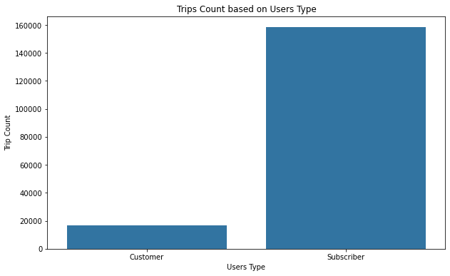

```python
plt.figure(figsize = [10, 6])
sb.countplot(data = df_clean, x ='user_type', color = base_color)
plt.title('Trips Count based on Users Type')
plt.xlabel('Users Type')
plt.ylabel('Trip Count');
```

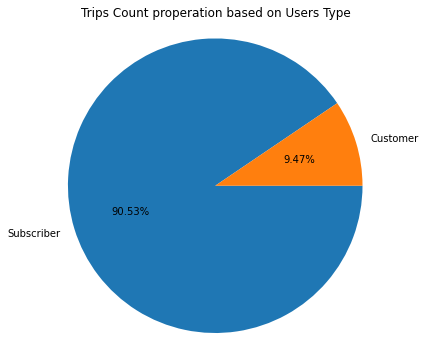

```python
plt.figure(figsize = [10, 6])
user = df_clean['user_type'].value_counts()
plt.pie(user, labels = user.index, counterclock = False, autopct='%1.2f%%')
plt.axis('square')
plt.title('Trips Count properation based on Users Type');
```

**Both charts show that the number of trips of Subscriber users is more than the number of trips of Customer users. In which (less than 160,000 trips of the total) 90.53% of the trips taken by Subscriber type whereas (less than 20,000 trips of the total) 9.47% of the trips taken by the customer type.**

### 2. member_gender

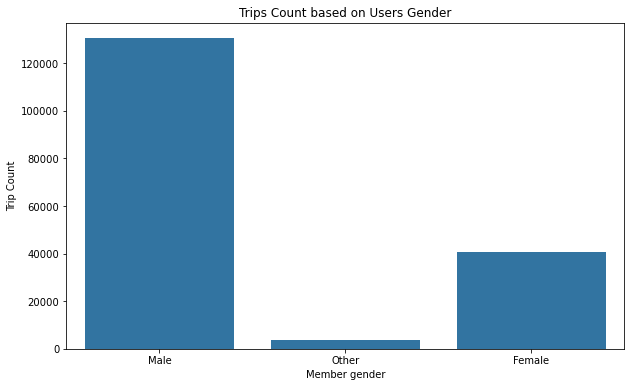

```python
plt.figure(figsize=[10, 6])
sb.countplot(data = df_clean, x ='member_gender', color = base_color)
plt.title('Trips Count based on Users Gender')
plt.xlabel('Member gender')
plt.ylabel('Trip Count');
```

**The above plot shows that the gender with higher trip count is Male, with more than 120,000 trips. And then Female gender with approximately 40,000 trips then the Other gender.**

### 3. member_age

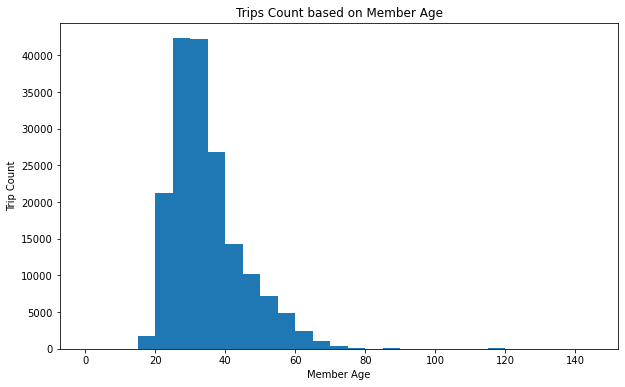

```python
bins = np.arange(0,df_clean['member_age'].max()+5,5)
plt.figure(figsize=[10, 6])
plt.hist(data = df_clean, x = 'member_age' , bins = bins)
plt.xlabel('Member Age')
plt.ylabel('Trip Count')
plt.title('Trips Count based on Member Age');
```

**From the above output we can see that there are some ages make no sense since they are above 80 , so I will drop them**

```python
# Drop rows with ages more than 80
df_clean.drop(df_clean[df_clean.member_age > 80].index, inplace=True)
```

```python
# display descriptive statistics of member_age
df_clean['member_age'].describe()
```

```
count    174760.000000
mean         34.125223
std           9.877739
min          18.000000
25%          27.000000
50%          32.000000
75%          39.000000
max          80.000000
Name: member_age, dtype: float64
```

```python
# Restore the clean dataFrame in a new CSV file
df_clean.to_csv('2019_02_fordgobike_clean.csv', header=True, index = False)
```

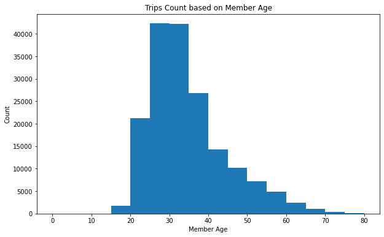

```python
bins = np.arange(0,df_clean['member_age'].max()+5,5)
plt.figure(figsize=[10, 6])
plt.hist(data = df_clean, x = 'member_age' , bins = bins)
plt.xlabel('Member Age')
plt.ylabel('Count')
plt.title('Trips Count based on Member Age');
```

**In the above histogram, we can see that the most bike trips are for members between 25-35 years old , and the number of trips gradually decreases as the age increases.**

### 4. bike_share_for_all_trip

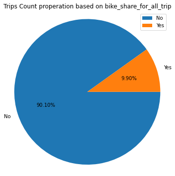

```python
plt.figure(figsize = [10, 6])
user = df_clean['bike_share_for_all_trip'].value_counts()
legend =  df_clean['bike_share_for_all_trip'].unique()
plt.pie(user, labels = user.index, counterclock = False, autopct='%1.2f%%')
plt.legend(legend)
plt.axis('square')
plt.title('Trips Count properation based on bike_share_for_all_trip');
```

### 5. Start_Day

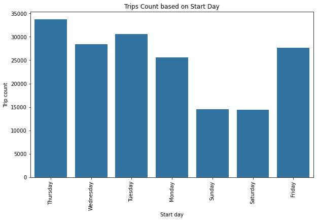

```python
plt.figure(figsize = [10, 6])
sb.countplot(data = df_clean, x ='start_Day', color = base_color)
plt.xticks(rotation=90)
plt.title('Trips Count based on Start Day')
plt.xlabel('Start day')
plt.ylabel('Trip count');
```

**Regardless the user type, it is clearly that on weekend the users take the least trips of the week. It is less than 15,000 trips. Whereas on Thursday the users take the most trips.**

```python
trip_counts = df_clean['start_Day'].value_counts()
trip_counts
```

```
Thursday     33691
Tuesday      30562
Wednesday    28396
Friday       27621
Monday       25588
Sunday       14492
Saturday     14410
Name: start_Day, dtype: int64
```

```python
# Returns the sum of all not-null values in `start_Day` column
n_trip = df_clean['start_Day'].value_counts().sum()

# Return the highest frequency in the `start_Day` column
max_trip_count = trip_counts[0]

# Return the maximum proportion, or in other words, compute the length of the longest bar in terms of the proportion
max_prop = max_trip_count / n_trip
print(max_prop)
```

```
0.1927843900205997
```

```python
# Use numpy.arange() function to produce a set of evenly spaced proportioned values between 0 and max_prop, with a step size 2\%
tick_props = np.arange(0, max_prop, 0.02)
tick_props
```

```
array([0.  , 0.02, 0.04, 0.06, 0.08, 0.1 , 0.12, 0.14, 0.16, 0.18])
```

```python
tick_names = ['{:0.2f}'.format(v) for v in tick_props]
tick_names
```

```
['0.00',
 '0.02',
 '0.04',
 '0.06',
 '0.08',
 '0.10',
 '0.12',
 '0.14',
 '0.16',
 '0.18']
```

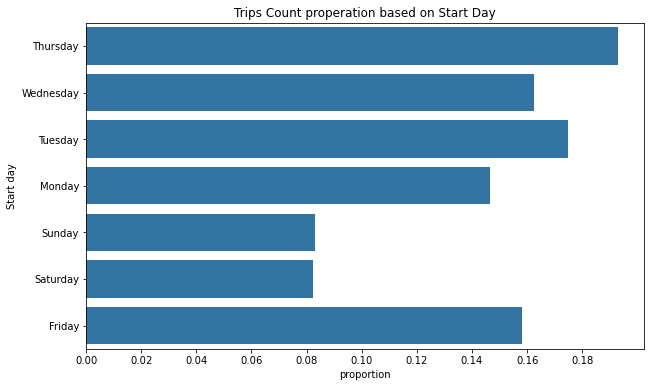

```python
plt.figure(figsize = [10, 6])
sb.countplot(data = df_clean, y = 'start_Day', color = base_color);
# Change the tick locations and labels
plt.xticks(tick_props * n_trip, tick_names)
plt.xlabel('proportion')
plt.ylabel('Start day')
plt.title('Trips Count properation based on Start Day');
```

**From the bar chart, we can see that the Tuesday, Wednesday & Thursday have the highest properation of bike trips in general. Thursday being the highest day with properation of more than 18.5%, followed by Tuesday then Wednesday with properation greater than 16% & less than 18%.**

**On the other hand, Saturday & Sunday have the lowest properation of bike trips overall. It is around 8%.**

### 6. duration_min

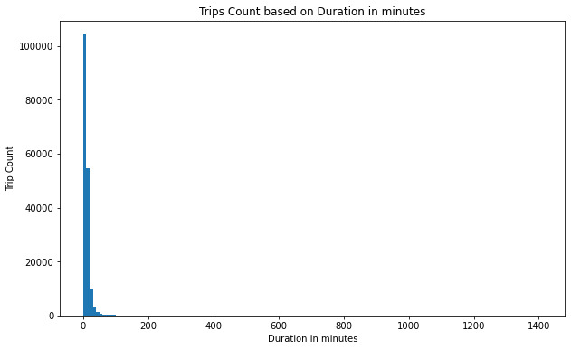

```python
plt.figure(figsize = [10, 6])
#  the third argument the bin width, I will change it till it become clear.
bins = np.arange(0, df_clean['duration_min'].max()+1, 10)
plt.hist(data = df_clean, x = 'duration_min', bins = bins)
plt.xlabel('Duration in minutes')
plt.ylabel('Trip Count')
plt.title('Trips Count based on Duration in minutes');
```

**Based on the above histogram, it is clear that the distribution of trips duration in minutes showen in the range less than 200. It is either because the existance of outliers or a very small number of values after the 200 minuts.**

**That why I will change the limit of the x axis.**

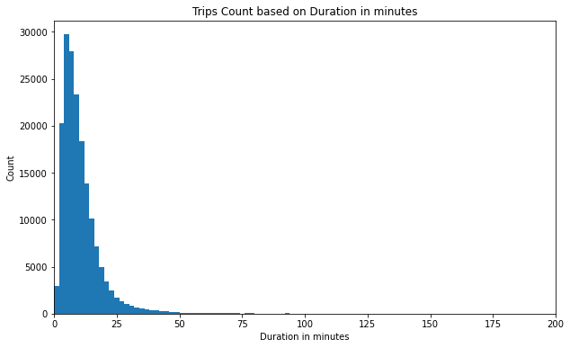

```python
bins = np.arange(0,df_clean['duration_min'].max(),2)
plt.figure(figsize=[10, 6])
plt.hist(data = df_clean, x = 'duration_min' , bins = bins)
plt.xlim((0 , 200))
plt.xlabel('Duration in minutes')
plt.ylabel('Count')
plt.title('Trips Count based on Duration in minutes');
```

**I've changed the limit of the x axis (to 200). Still it needs to be changed again, to make the plot clearly readable.**

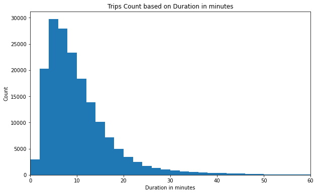

```python
bins = np.arange(0,df_clean['duration_min'].max(),2)
plt.figure(figsize=[10, 6])
plt.hist(data = df_clean, x = 'duration_min' , bins = bins)
plt.xlim((0 , 60))
plt.xlabel('Duration in minutes')
plt.ylabel('Count')
plt.title('Trips Count based on Duration in minutes');
```

**The histogram above shows that the majority of trips had duration of less than 1 hour, and most of them are between 2 to 12 range of minutes.**

### Discuss the distribution(s) of your variable(s) of interest. Were there any unusual points? Did you need to perform any transformations?

**The distribution of variables of interest:**

- 90.53% of the trips taken by Subscriber type whereas 9.47% of the trips taken by the customer type. Most of the members are Male & they are between 25-35 years old. Also, 90.10% of the members are not sharing the bike for all trip.
- Thursday has the highest number of trips with properation of more than 18.5% followed by Tuesday then Wednesday with properation greater than 16% & less than 18%.
- The majority of trips had duration of less than 1 hour, and most of them are between 2 to 12 range of minutes.

**The existance of unusual points:**

- The distribution of trips duration in minutes showen in the range less than 200 there was a lot of data points with low values. It is either because the existance of outliers or a very small number of values after the 200 minuts.That why I changed the limit of the x axis. Also, I changed the third argument of the np.arange() function which is the bin width to make the plot clearley readable.

### Of the features you investigated, were there any unusual distributions? Did you perform any operations on the data to tidy, adjust, or change the form of the data? If so, why did you do this?

- I've performed changes in the copied dataset, added a new column for the member age and added new columns for each variable in start_time & end_time columns. Also, I've rearrenged the columns order in the copied dataset.

## Bivariate Exploration

### 1. duration_min vs. user_type

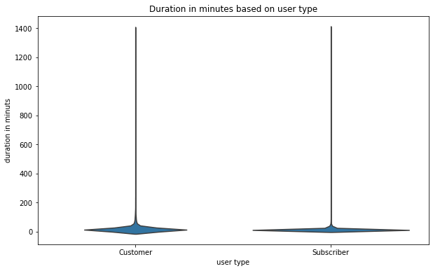

```python
plt.figure(figsize=[10, 6])
sb.violinplot(data=df_clean, x='user_type', y='duration_min', color=base_color, inner=None)
plt.title('Duration in minutes based on user type')
plt.xlabel('user type')
plt.ylabel('duration in minuts');
```

**Since most of the data are in the range below 200 minutes so I will make a sub dataframe with duration_min < 200. The condition may need to be changed till the plot is readable clearly**

> reference: https://www.geeksforgeeks.org/selecting-rows-in-pandas-dataframe-based-on-conditions/

```python
duration_df = df_clean[df_clean['duration_min'] < 80]
```

**I've changed the condition different times, the first one was < 200 and still the data is so close that is difficult to read and analyze, then I tried several times untill I got the plot clear with duration_min < 80 or in another words less than 1 hour 20 minutes**

```python
duration_df
```

|  | bike_id | user_type | member_gender | member_birth_year | member_age | bike_share_for_all_trip | duration_min | start_station_name | end_station_name | start_Date | start_Hour | start_Day | start_Month | end_Date | end_Hour | end_Day | end_Month |
| --- | --- | --- | --- | --- | --- | --- | --- | --- | --- | --- | --- | --- | --- | --- | --- | --- | --- |
| 4 | 4898 | Subscriber | Male | 1974 | 45 | Yes | 26.416667 | Frank H Ogawa Plaza | 10th Ave at E 15th St | 2019-02-28 | 23 | Thursday | February | 2019-03-01 | 0 | Friday | March |
| 5 | 5200 | Subscriber | Male | 1959 | 60 | No | 29.883333 | 4th St at Mission Bay Blvd S | Broadway at Kearny | 2019-02-28 | 23 | Thursday | February | 2019-03-01 | 0 | Friday | March |
| 6 | 3803 | Subscriber | Female | 1983 | 36 | No | 19.116667 | Palm St at Willow St | San Jose Diridon Station | 2019-02-28 | 23 | Thursday | February | 2019-03-01 | 0 | Friday | March |
| 7 | 6329 | Subscriber | Male | 1989 | 30 | No | 26.916667 | Washington St at Kearny St | Valencia St at 21st St | 2019-02-28 | 23 | Thursday | February | 2019-03-01 | 0 | Friday | March |
| 8 | 6548 | Subscriber | Other | 1988 | 31 | No | 26.166667 | Washington St at Kearny St | Valencia St at 21st St | 2019-02-28 | 23 | Thursday | February | 2019-03-01 | 0 | Friday | March |
| ... | ... | ... | ... | ... | ... | ... | ... | ... | ... | ... | ... | ... | ... | ... | ... | ... | ... |
| 183407 | 4832 | Subscriber | Male | 1996 | 23 | No | 8.000000 | Beale St at Harrison St | Union Square (Powell St at Post St) | 2019-02-01 | 0 | Friday | February | 2019-02-01 | 0 | Friday | February |
| 183408 | 4960 | Subscriber | Male | 1984 | 35 | No | 5.216667 | Montgomery St BART Station (Market St at 2nd St) | 3rd St at Townsend St | 2019-02-01 | 0 | Friday | February | 2019-02-01 | 0 | Friday | February |
| 183409 | 3824 | Subscriber | Male | 1990 | 29 | Yes | 2.350000 | The Alameda at Bush St | Morrison Ave at Julian St | 2019-02-01 | 0 | Friday | February | 2019-02-01 | 0 | Friday | February |
| 183410 | 5095 | Subscriber | Male | 1988 | 31 | No | 2.316667 | San Pablo Ave at MLK Jr Way | San Pablo Ave at 27th St | 2019-02-01 | 0 | Friday | February | 2019-02-01 | 0 | Friday | February |
| 183411 | 1057 | Subscriber | Male | 1989 | 30 | No | 4.516667 | Spear St at Folsom St | 2nd St at Folsom St | 2019-02-01 | 0 | Friday | February | 2019-02-01 | 0 | Friday | February |

173829 rows × 17 columns

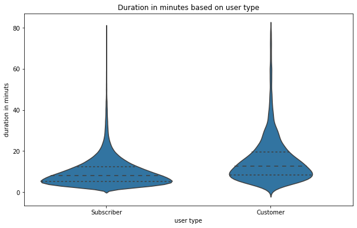

```python
plt.figure(figsize = [10, 6])
sb.violinplot(data=duration_df, x='user_type', y='duration_min', color=base_color, inner='quartile')
plt.title('Duration in minutes based on user type')
plt.xlabel('user type')
plt.ylabel('duration in minuts');
```

**Obviously the cutomer user type have longer trip duration in minutes than the subscriber type. It seems like the customer will rent the bike and use it instantaneously. Whereas subscribers feel they are not in a rush to use the bike since they already have the annual subscription.**

### 2. duration_min vs. member_age

#### 2.1 The data are from the copied data frame (df_clean)

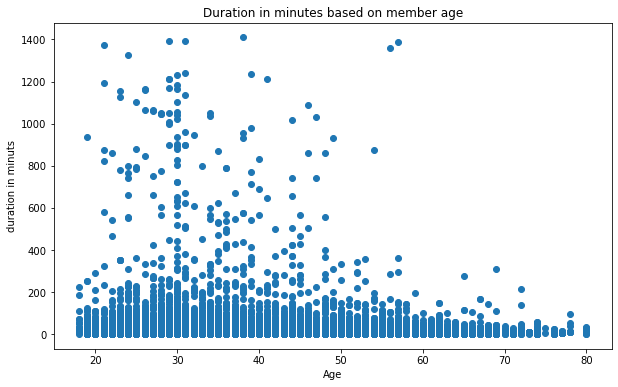

```python
plt.figure(figsize=[10, 6])
plt.scatter(data = df_clean,  x = 'member_age', y = 'duration_min');
plt.title('Duration in minutes based on member age')
plt.xlabel('Age')
plt.ylabel('duration in minuts');
```

#### 2.2 The data are from the sub data frame (duration_df)

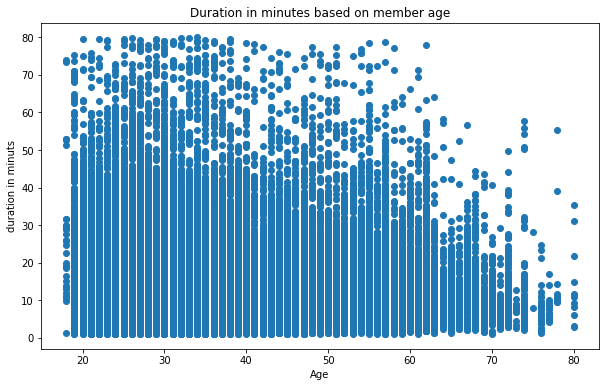

```python
plt.figure(figsize=[10, 6])
plt.scatter(data = duration_df,  x = 'member_age', y = 'duration_min');
plt.title('Duration in minutes based on member age')
plt.xlabel('Age')
plt.ylabel('duration in minuts');
```

**Trips taken by members with age above 65 are almost 60 minutes or less, whereas the members with age under 65 took more than an hour.**

### 3. duration_min vs. start_Day

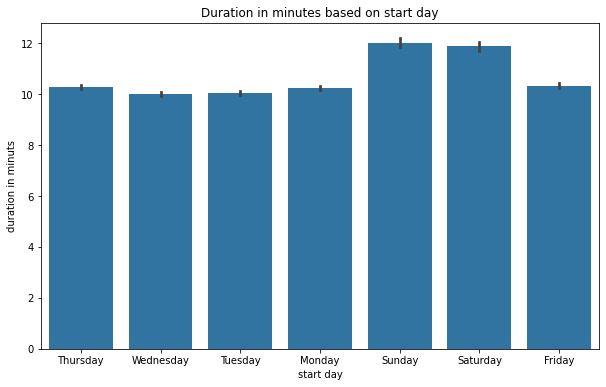

```python
plt.figure(figsize = [10, 6])
sb.barplot(data=duration_df, x='start_Day', y='duration_min', color=base_color)
plt.title('Duration in minutes based on start day')
plt.xlabel('start day')
plt.ylabel('duration in minuts');
```

**The duration of trips on weekends (Saturday & Sunday) are higher than the trips on the weekdays.**

### 4. user_type vs. bike_share_for_all_trip

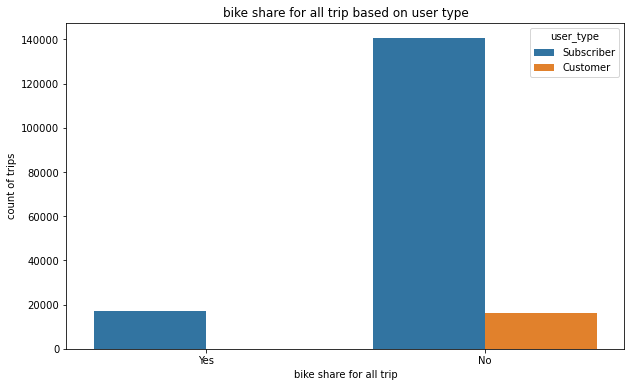

```python
plt.figure(figsize = [10, 6])
sb.countplot(data = duration_df, x = 'bike_share_for_all_trip', hue = 'user_type')
plt.title('bike share for all trip based on user type')
plt.xlabel('bike share for all trip')
plt.ylabel('count of trips');
```

**The above plot shows that the customer members do not share the bike for all the trip at all. Whereas the subscriber members share a few number of bike for all trips on the other hand the majority of the subscribers do not share the bike.**

**I will add labels on top of each bar to illustrate**

> reference https://datavizpyr.com/how-to-annotate-bars-in-barplot-with-matplotlib-in-python/

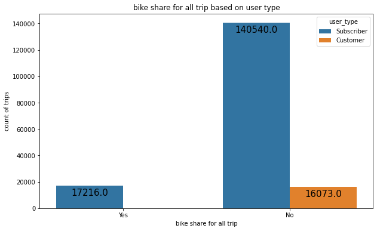

```python
plt.figure(figsize = [10, 6])

splot = sb.countplot(data = duration_df, x = 'bike_share_for_all_trip', hue = 'user_type')

for p in splot.patches:
    splot.annotate(format(p.get_height(), '.1f'),
                   (p.get_x() + p.get_width() / 2., p.get_height()),
                   ha = 'center', va = 'center',
                   size=15,
                   xytext = (0, -12),
                   textcoords = 'offset points')
plt.title('bike share for all trip based on user type')
plt.xlabel('bike share for all trip')
plt.ylabel('count of trips');
```

### Did you observe any interesting relationships between the other features (not the main feature(s) of interest)?

- No other relationships were observed.

## Multivariate Exploration

### 1. duration_min vs. start_Day based on user_type

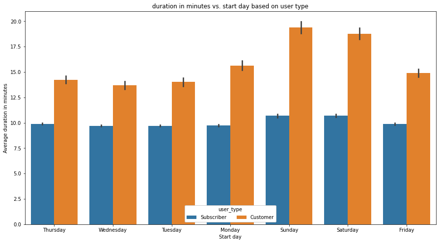

```python
plt.figure(figsize = [15, 8])
ax = sb.barplot(data = duration_df, x = 'start_Day', y = 'duration_min', hue = 'user_type')
ax.legend(loc = 8, ncol = 3, framealpha = 1, title = 'user_type')
plt.xlabel('Start day')
plt.ylabel('Average duration in minutes')
plt.title('duration in minutes vs. start day based on user type');
```

**The average duration of trips for subscriber user type among the week days is the almost the same. Whereas the average duration of trips for customer user type among the week days is jumped to its highest on the weekends, and the rest of the week day it almost closely similar.**

### 2. duration_min vs. start_Hour based on member_age

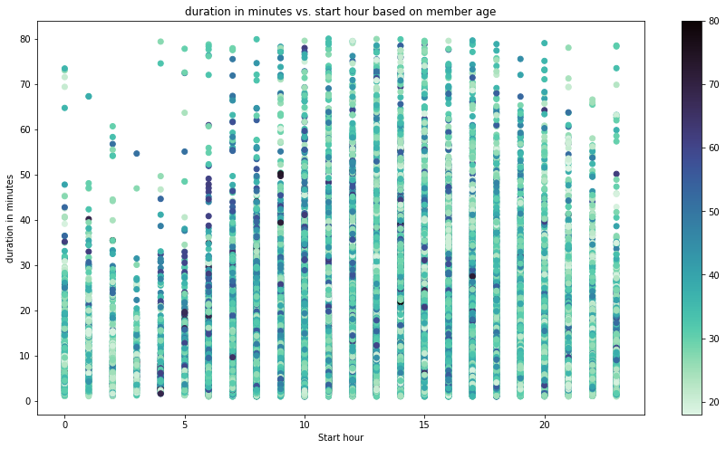

```python
plt.figure(figsize = [15, 8])
plt.scatter(data = duration_df, x = 'start_Hour', y = 'duration_min', c = 'member_age', cmap = 'mako_r')
plt.colorbar()
plt.title('duration in minutes vs. start hour based on member age')
plt.xlabel('Start hour')
plt.ylabel('duration in minutes');
```

### Were there any interesting or surprising interactions between features?

No there are not.